# Build food webs

```r
library(renv)
renv::load()
library(targets)
library(here)
tar_config_set(
  store = here::here("_targets")
)
library(foodwebbuilder)
library(dplyr)
library(tibble)
library(riversea)
library(ggplot2)
set_theme(theme_minimal())
library(INLA)
```

## Build the metaweb

To build the metaweb, we need the following.

The diet table for fish species considered.

```r
diet_fish <- tar_read(diet)
head(diet_fish)
```

```
# A tibble: 6 × 15
  species        stage length_min length_max crustacean insect  worm zooplankton
  <chr>          <chr>      <dbl>      <dbl>      <dbl>  <dbl> <dbl>       <dbl>
1 Abramis brama  1           0          0.98          0      0     0           1
2 Abramis brama  2           0.98       1.71          0      0     0           1
3 Abramis brama  3           1.71      12.0           0      0     0           1
4 Abramis brama  4          12.0      Inf             1      1     0           0
5 Acipenser rut… 0           0        Inf             1      1     0           0
6 Agonus cataph… larv…       0          2             0      0     0           1
# ℹ 7 more variables: detritus <dbl>, macrophyte <dbl>, mollusk <dbl>,
#   fish <dbl>, biofilm <dbl>, phytoplankton <dbl>, echinoderm <dbl>
```

The diet for the resources considered.

```r
diet_resource <- tar_read(diet_resource)
```

The size of each individual fish.

```r
size <- tar_read(sea_data_imputed)$size
head(size)
```

```
     trait length year survey species_valid measured
1 61836630    6.3 2016  pomet Abramis brama     TRUE
2 61836630    5.5 2016  pomet Abramis brama     TRUE
3 61836630    7.0 2016  pomet Abramis brama     TRUE
4 61836630    6.5 2016  pomet Abramis brama     TRUE
5 61836630   19.3 2016  pomet Abramis brama     TRUE
6 61836630    6.1 2016  pomet Abramis brama     TRUE
```

The predation window.

```r
predation_window <- tar_read(predation_window)
head(predation_window)
```

```
# A tibble: 6 × 3
  species               beta_min beta_max
  <chr>                    <dbl>    <dbl>
1 Alosa alosa               0.03     0.45
2 Alosa fallax              0.03     0.45
3 Ambloplites rupestris     0.03     0.45
4 Ameiurus melas            0.03     0.45
5 Anguilla anguilla         0.03     0.45
6 Argyrosomus regius        0.03     0.45
```

From this we can build the metaweb using helper functions of the `foodwebbuilder` package. We wrapped them in a `riversea` function so the metaweb can be build directly. We just need to specify the number of size class, and the selected resources, although default values are set if not specified.

For information, here is the structure that we consider between the different trophic groups on which fish can feed on.

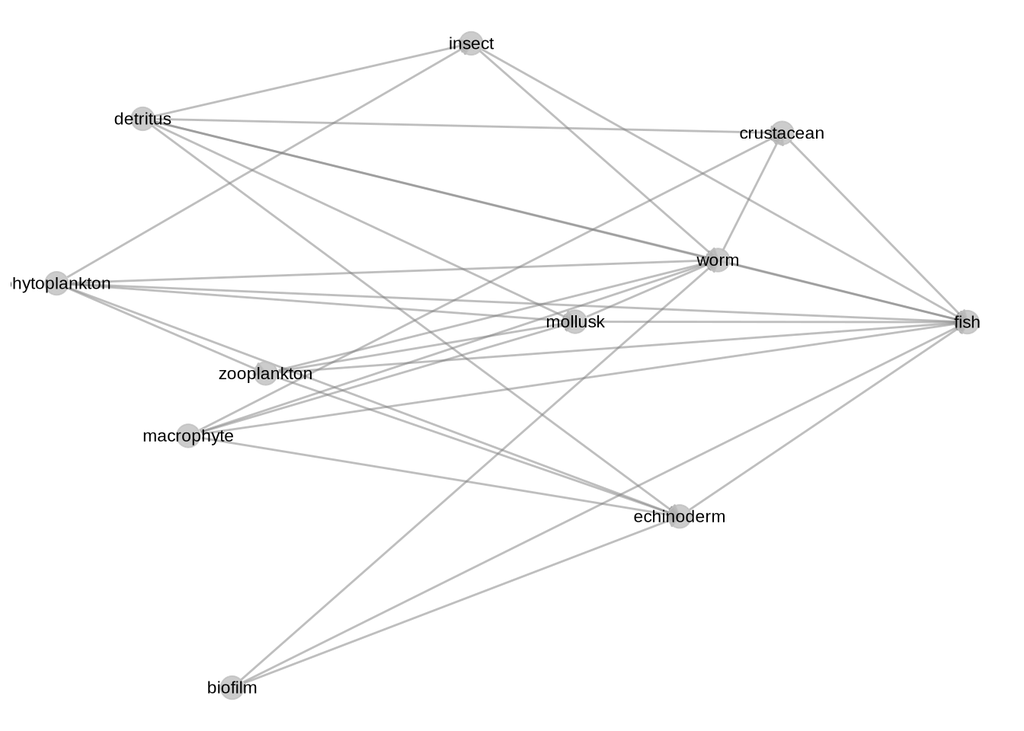

```r
tar_read(plot_net_groups)
```

We have already computed metaweb for different number of size classes, so we can check whether this parameter influences the metaweb structure.

```r
metaweb_table <- tar_read(metaweb_table)
metaweb_table
```

```
# A tibble: 7 × 2
  num_classes metaweb
        <int> <list>
1           3 <dbl [334 × 334]>
2           4 <dbl [442 × 442]>
3           5 <dbl [550 × 550]>
4           6 <dbl [658 × 658]>
5           7 <dbl [766 × 766]>
6           8 <dbl [874 × 874]>
7           9 <dbl [982 × 982]>
```

We can plot the metaweb connectance against the number of size classes.

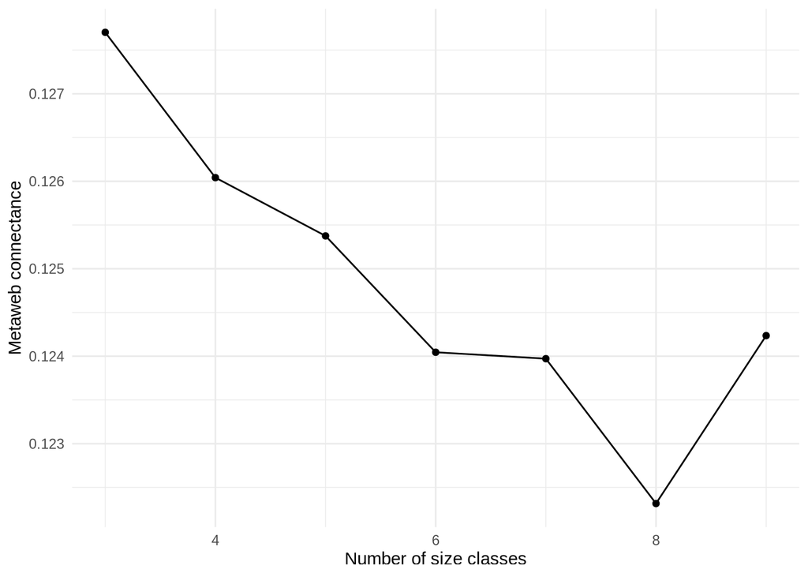

```r
tar_read(plot_metaweb_connectance)
```

We observe little variation indicating that the number of size class does not change too much the structure of the food web reconstructed.

## Get local food webs

```r
web_list <- tar_read(web_list)

get_connectance(web_list$metaweb)
```

```
[1] 0.119312
```

```r
local_foodwebs <- tar_read(local_foodwebs)
head(local_foodwebs)
```

```
# A tibble: 6 × 14
  operation_id foodweb  log_trophic_richness log_species_richness connectance
  <chr>        <list>                  <dbl>                <dbl>       <dbl>
1 61836630     <dbl[…]>                 3.00                 2.83       0.132
2 61832572     <dbl[…]>                 3.04                 2.83       0.132
3 61835462     <dbl[…]>                 2.89                 2.89       0.142
4 61832074     <dbl[…]>                 2.94                 2.77       0.155
5 61836249     <dbl[…]>                 2.94                 2.56       0.197
6 61837171     <dbl[…]>                 2.48                 2.40       0.208
# ℹ 9 more variables: trophic_length <dbl>, trophic_breadth_q90 <dbl>,
#   trophic_breadth_median <dbl>, frac_piscivorous <dbl>, year <dbl>,
#   month <dbl>, longitude <dbl>, latitude <dbl>, survey <chr>
```

```r
trait_data <- tar_read(sea_data_tidy)$trait
local_foodwebs <- local_foodwebs |>
  left_join(trait_data)
head(local_foodwebs)
```

```
# A tibble: 6 × 16
  operation_id foodweb  log_trophic_richness log_species_richness connectance
  <chr>        <list>                  <dbl>                <dbl>       <dbl>
1 61836630     <dbl[…]>                 3.00                 2.83       0.132
2 61832572     <dbl[…]>                 3.04                 2.83       0.132
3 61835462     <dbl[…]>                 2.89                 2.89       0.142
4 61832074     <dbl[…]>                 2.94                 2.77       0.155
5 61836249     <dbl[…]>                 2.94                 2.56       0.197
6 61837171     <dbl[…]>                 2.48                 2.40       0.208
# ℹ 11 more variables: trophic_length <dbl>, trophic_breadth_q90 <dbl>,
#   trophic_breadth_median <dbl>, frac_piscivorous <dbl>, year <dbl>,
#   month <dbl>, longitude <dbl>, latitude <dbl>, survey <chr>, trait <chr>,
#   salinity <dbl>
```

We have computed the connectance and richness of local metaweb so we can plot the relationship between these two variables.

```r
m1 <- inla(
  connectance ~ 1 + log_trophic_richness + f(survey, model = "iid") + f(year, model = "iid"),
  data = local_foodwebs |> select(-foodweb)
)
summary(m1)
```

```
Time used:
    Pre = 0.527, Running = 0.471, Post = 0.101, Total = 1.1
Fixed effects:
                       mean    sd 0.025quant 0.5quant 0.975quant   mode kld
(Intercept)           0.382 0.009      0.363    0.382      0.401  0.382   0
log_trophic_richness -0.070 0.000     -0.071   -0.070     -0.069 -0.070   0

Random effects:
  Name    Model
    survey IID model
   year IID model

Model hyperparameters:
                                            mean      sd 0.025quant 0.5quant
Precision for the Gaussian observations  3503.54   32.35    3440.26  3503.39
Precision for survey                     6435.75 4924.30    1101.99  5132.27
Precision for year                      20860.56 5126.12   12492.47 20285.70
                                        0.975quant     mode
Precision for the Gaussian observations    3567.64  3503.12
Precision for survey                      19332.71  2967.05
Precision for year                        32544.42 19212.49

Marginal log-Likelihood:  62409.66
 is computed
Posterior summaries for the linear predictor and the fitted values are computed
(Posterior marginals needs also 'control.compute=list(return.marginals.predictor=TRUE)')
```

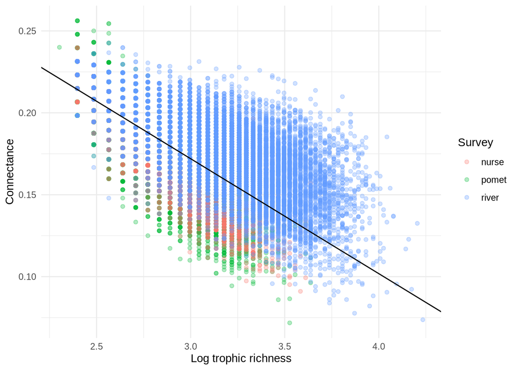

```r
intercept <- m1$summary.fixed["(Intercept)", "mean"]
slope <- m1$summary.fixed["log_trophic_richness", "mean"]

ggplot(local_foodwebs, aes(x = log_trophic_richness, y = connectance, color = survey)) +
  geom_point(alpha  = 0.3) +
  geom_abline(intercept = intercept, slope = slope) +
  labs(x = "Log trophic richness", y = "Connectance", color = "Survey")
```

As expected, we observe a negative trend between connectance and species richness. There is also a small random effect attributed to the survey.

Next, we investigate the effect of the year on species richness.

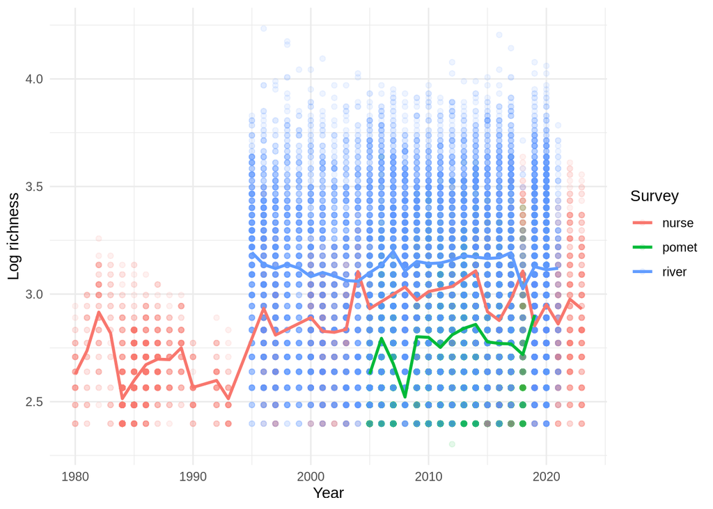

```r
ggplot(local_foodwebs, aes(x = year, y = log_trophic_richness, color = survey)) +
  geom_point(alpha  = 0.1) +
  stat_summary(
    fun = mean,
    geom = "line",
    linewidth = 1
  ) +
  labs(x = "Year", y = "Log richness", color = "Survey")
```

As we observe a positive trend between richness and year, and that we have observed a negative trend between richness and connectance, we expect a negative trend between connectance and year.

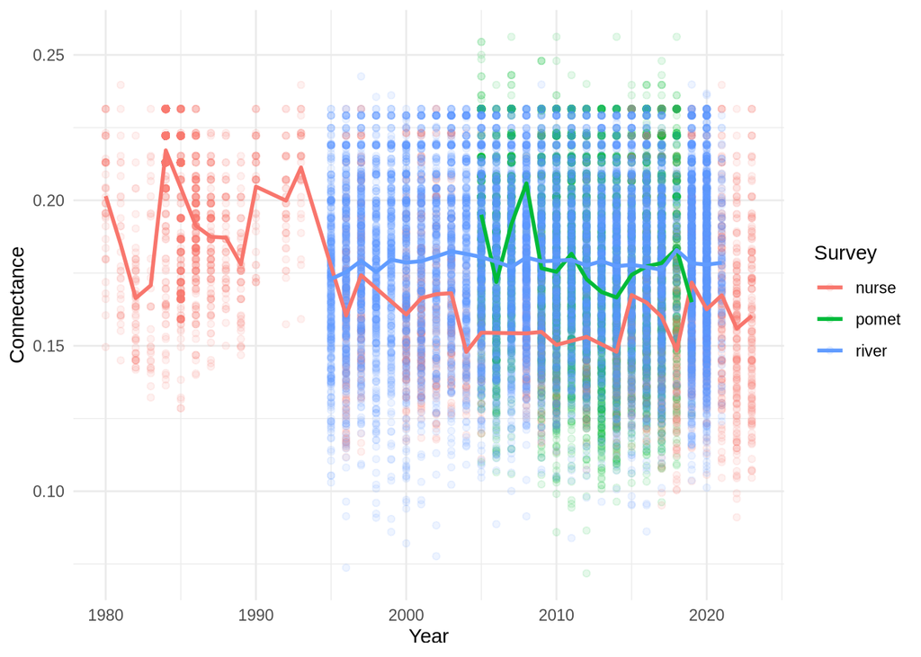

```r
ggplot(local_foodwebs, aes(x = year, y = connectance, color = survey)) +
  geom_point(alpha  = 0.1) +
  stat_summary(
    fun = mean,
    geom = "line",
    linewidth = 1
  ) +
  labs(x = "Year", y = "Connectance", color = "Survey")
```